# Laboratory Session - March 31, 2022

# Paolo Zinesi 2053062

```r
set.seed(12345)

library(ggplot2)
library(gridExtra)
library(GoFKernel)
```

## Exercise 1

A set of measurements have been performed on the concentration of a contaminant in tap water.

```r
x <- c(15.58, 15.9, 16, 16.1, 16.2)
p1 <- c(0.15, 0.21, 0.35, 0.15, 0.14)
p2 <- c(0.14, 0.05, 0.64, 0.08, 0.09)


e1 <- sum(x*p1)
e2 <- sum(x*p2)
var1 <- sum((x*x)*p1) - e1*e1
var2 <- sum((x*x)*p2) - e2*e2

cat("Method 1: expected value =", round(e1,3), ", variance =", round(var1,3))
```

```
Method 1: expected value = 15.959 , variance = 0.034
```

```r
cat("\nMethod 2: expected value =", round(e2,3), ", variance =", round(var2,3))
```

```
Method 2: expected value = 15.962 , variance = 0.028
```

## Exercise 2

The waiting time, in minutes, at the doctor’s is about 30 minutes, and the distribution follows an exponential pdf with rate 1/30

```r
# ∆t = 1 min
rate <- 1/30
wait_sim <- rexp(50, rate = rate)

hist(wait_sim, main = "Waiting times histogram (N=50)", xlab = "Time (min)", ylab = "Counts")
grid()
```

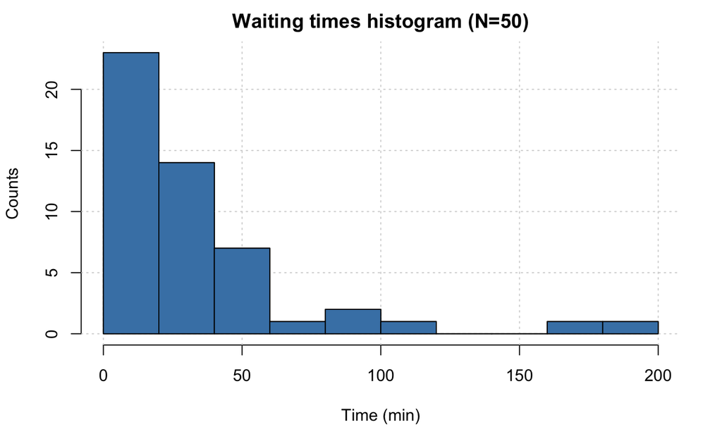

```r
hist(wait_sim,
     col="steelblue", add=TRUE)
```

```r
prob_less10min <- pexp(10, rate = rate)
cat("The probability that a person will wait less than 10 minutes is", round(prob_less10min*100,1), "%")
```

```
The probability that a person will wait less than 10 minutes is 28.3 %
```

```r
sim_mean <- mean(wait_sim)
thr1_expectvalue <- 1/rate
thr2_expectvalue <- integrate( function(x) {x*dexp(x, rate = rate)}, lower = 0, upper = Inf)


cat("Average waiting time in the simulation =", round(sim_mean,2), "min\n")
```

```
Average waiting time in the simulation = 34.04 min
```

```r
cat("Average waiting time by the definition =", thr1_expectvalue, "min\n")
```

```
Average waiting time by the definition = 30 min
```

```r
cat("Average waiting time by the integral = (", thr2_expectvalue[["value"]], "±", round(thr2_expectvalue[["abs.error"]], digits=6), ") min\n")
```

```
Average waiting time by the integral = ( 30 ± 2.5e-05 ) min
```

```r
prob_more1h <- (1-pexp(60, rate = rate))
cat("The probability that a person will wait more than 1 hour is", round(prob_more1h*100,1), "%")
```

```
The probability that a person will wait more than 1 hour is 13.5 %
```

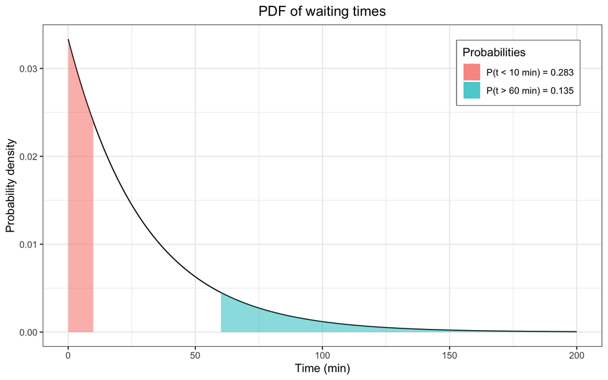

```r
x_doctor <- seq(0,200,0.1)
pdf_doctor <- data.frame(x=x_doctor, y=dexp(x_doctor, rate = rate))

prob_plt_doctor <- ggplot(data=pdf_doctor, mapping=aes(x=x, y=y)) +
                        labs(title="PDF of waiting times", fill = "Probabilities") +
                        geom_line(data=pdf_doctor, aes(x = x, y = y), size=0.5) +
                        geom_area(data=pdf_doctor,
                                  aes(x = ifelse(x>0 & x<10, x, 0), fill = paste(c("P(t < 10 min) =",round(prob_less10min,3)), collapse = " ")),
                                  alpha = 0.5) +
                        geom_area(data=pdf_doctor,
                                  aes(x = ifelse(x>60, x, 0), fill = paste(c("P(t > 60 min) =",round(prob_more1h,3)), collapse = " ")),
                                  alpha = 0.5) +
                        scale_x_continuous(name ="Time (min)") +
                        scale_y_continuous(name ="Probability density", limits = c(0, max(pdf_doctor$y))) +
                        theme_bw() +
                        theme(plot.title=element_text(hjust=0.5), legend.position = c(0.85,0.85), legend.box.background = element_rect(size=0.5))

prob_plt_doctor
```

## Exercise 3

Let’s suppose that on a book, on average, there is one typo error every three pages. The number of errors follows a Poisson distribution.

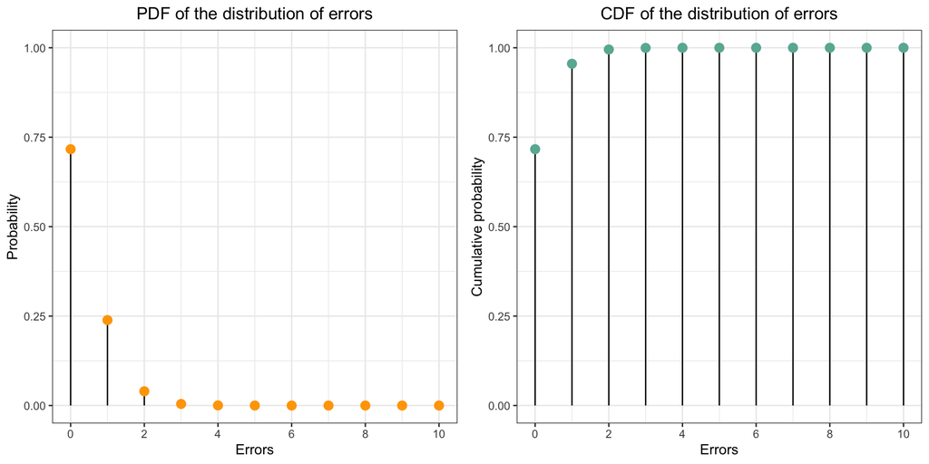

```r
#par(mfrow=c(1, 2), mar=c(2,2,2,2))

# ∆N = 1 pag
rate <- 1/3

x_books <- c(0:10)
pdf_books <- data.frame(x=x_books, y=dpois(x_books , lambda=rate))
cdf_books <- data.frame(x=x_books, y=ppois(x_books , lambda=rate))

pdf_plt_books <- ggplot(pdf_books, aes(x=x, y=y)) +
                        labs(title="PDF of the distribution of errors") +
                        geom_segment(aes(x=x, xend=x, y=0, yend=y)) +
                        geom_point(size=3, color='orange') +
                        scale_x_continuous(name ="Errors", breaks=seq(0,10,2)) +
                        scale_y_continuous(name ="Probability", limits = c(0,1)) +
                        theme_bw() +
                        theme(plot.title=element_text(hjust=0.5))

cdf_plt_books <- ggplot(cdf_books, aes(x=x, y=y)) +
                        labs(title="CDF of the distribution of errors") +
                        geom_segment(aes(x=x, xend=x, y=0, yend=y)) +
                        geom_point(size=3, color='#69b3a2') +
                        scale_x_continuous(name ="Errors", breaks=seq(0,10,2)) +
                        scale_y_continuous(name ="Cumulative probability", limits = c(0,1)) +
                        theme_bw() +
                        theme(plot.title=element_text(hjust=0.5))

grid.arrange(pdf_plt_books, cdf_plt_books, nrow = 1)
```

```r
prob_more1error <- 1 - ppois(0 , lambda=rate)
cat("The probability that there is at least one error on a specific page of the book is", round(prob_more1error*100,1), "%")
```

```
The probability that there is at least one error on a specific page of the book is 28.3 %
```

## Exercise 4

We randomly draw cards from a deck of 52 cards, with replacement, until one ace is drawn. Calculate the probability that at least 10 draws are needed.

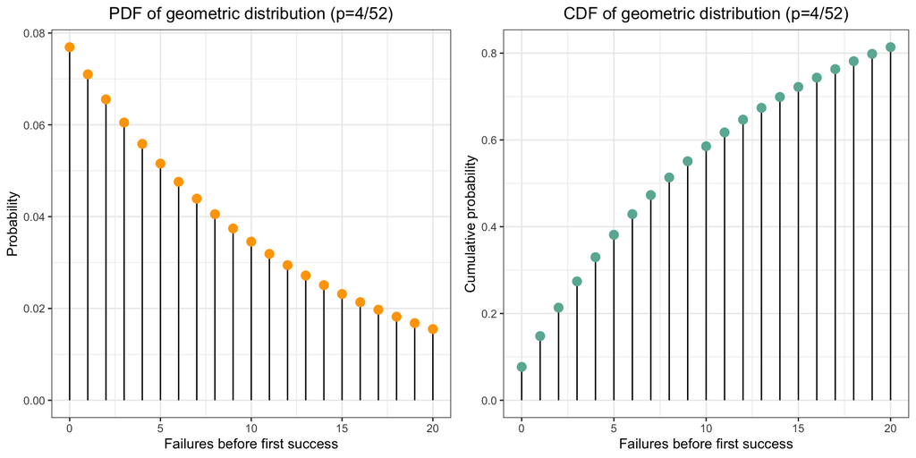

```r
prob <- 4/52

x_cards <- c(0:20)
pdf_cards <- data.frame(x=x_cards, y=dgeom(x_cards, prob=prob))
cdf_cards <- data.frame(x=x_cards, y=pgeom(x_cards, prob=prob))

pdf_plt_cards <- ggplot(pdf_cards, aes(x=x, y=y)) +
                        labs(title="PDF of geometric distribution (p=4/52)") +
                        geom_segment(aes(x=x, xend=x, y=0, yend=y)) +
                        geom_point(size=3, color='orange') +
                        scale_x_continuous(name ="Failures before first success") +
                        scale_y_continuous(name ="Probability") +
                        theme_bw() +
                        theme(plot.title=element_text(hjust=0.5))

cdf_plt_cards <- ggplot(cdf_cards, aes(x=x, y=y)) +
                        labs(title="CDF of geometric distribution (p=4/52)") +
                        geom_segment(aes(x=x, xend=x, y=0, yend=y)) +
                        geom_point(size=3, color='#69b3a2') +
                        scale_x_continuous(name ="Failures before first success") +
                        scale_y_continuous(name ="Cumulative probability") +
                        theme_bw() +
                        theme(plot.title=element_text(hjust=0.5))

grid.arrange(pdf_plt_cards, cdf_plt_cards, nrow = 1)
```

With the terminology of this distribution definition, calculating the probability that at least 10 draws are needed is equivalent to calculate the probability that at least 9 failures occurred before the first success.

```r
prob_more9fails <- 1 - pgeom(8, prob=prob)
cat("The probability that at least 10 draws are needed until we draw an ace is", round(prob_more9fails*100,1), "%")
```

```
The probability that at least 10 draws are needed until we draw an ace is 48.7 %
```

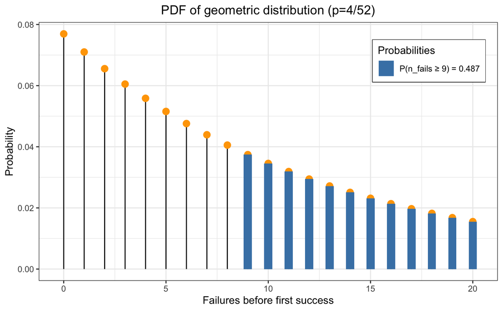

```r
prob_plt_cards <- pdf_plt_cards +
                  labs(fill = "Probabilities") +
                  geom_col(data=pdf_cards,
                           aes(x=ifelse(x>=9, x, 0), y=ifelse(x>=9, y, 0), fill = paste(c("P(n_fails ≥ 9) =", round(prob_more9fails,3)), collapse = " ")),
                           alpha=1, size=0.5, width = 0.4) +
                  scale_fill_manual(values="steelblue") +
                  theme(legend.position = c(0.85,0.85), legend.box.background = element_rect(size=0.5))

prob_plt_cards
```

## Exercise 5

### Exercise 5a

Determine the constant c.

```r
c_inverse_integral <- integrate( function(t) {(t-1)*(2-t)}, lower = 1, upper = 2)
c_inverse_thr <- 1/6
c_integral <- 1/c_inverse_integral[["value"]]

cat("The inverse of c is, by the integral, (", signif(c_inverse_integral[["value"]],3), "±", signif(c_inverse_integral[["abs.error"]],2), ")\n")
```

```
The inverse of c is, by the integral, ( 0.167 ± 1.9e-15 )
```

```r
cat("The inverse of c is, analytically,", signif(c_inverse_thr,3), "\n\n")
```

```
The inverse of c is, analytically, 0.167
```

```r
cat("The value of c, by the analytic integral, is", c_integral)
```

```
The value of c, by the analytic integral, is 6
```

### Exercise 5b

Write the set of the four functions (PDF, CDF, quantile function, random generation) and plot the PDF and CDF, respectively.

```r
# PDF
dTOLC <- Vectorize(FUN = function(x) { return(ifelse( (x>1) && (x<2), c_integral*(x-1)*(2-x), 0)) })

# CDF
pTOLC <- Vectorize(FUN = function(q) { if (q<1) { return(0) }
                                       else if (q>2) { return(1) }
                                       else { return(integrate(dTOLC, lower = 1, upper = q)[["value"]]) }
                                     })

# quantile function
qTOLC <- Vectorize(FUN = inverse(pTOLC, lower = 1, upper = 2))

# random generation
rTOLC <- function(n) { return(qTOLC(runif(n, min = 0, max = 1))) }
```

Plot the PDF and CDF.

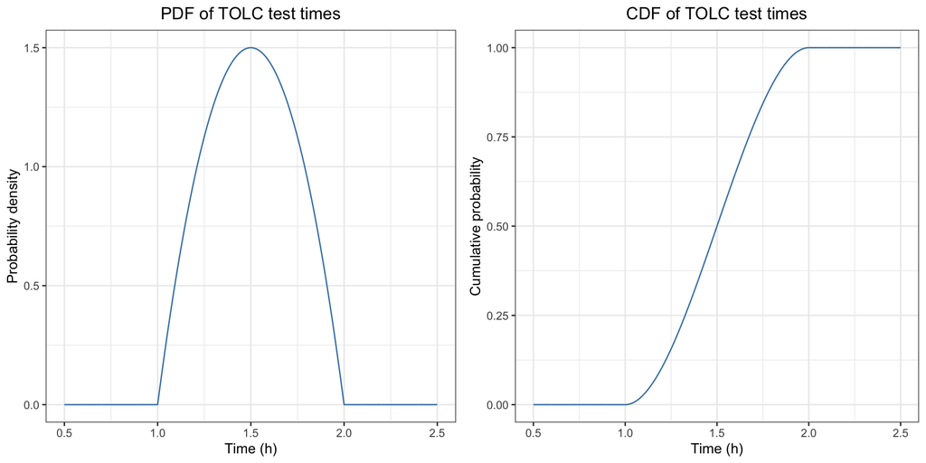

```r
# ∆t = 1h
x_TOLC <- seq(1-0.5,2+0.5,0.001)
pdf_TOLC <- data.frame(x=x_TOLC, y=dTOLC(x_TOLC))
cdf_TOLC <- data.frame(x=x_TOLC, y=pTOLC(x_TOLC))

pdf_plt_TOLC <- ggplot(pdf_TOLC, aes(x=x, y=y)) +
                        labs(title="PDF of TOLC test times") +
                        geom_line(data=pdf_TOLC, aes(x = x, y = y), color='steelblue', size=0.5) +
                        scale_x_continuous(name ="Time (h)") +
                        scale_y_continuous(name ="Probability density") +
                        theme_bw() +
                        theme(plot.title=element_text(hjust=0.5))

cdf_plt_TOLC <- ggplot(cdf_TOLC, aes(x=x, y=y)) +
                        labs(title="CDF of TOLC test times") +
                        geom_line(data=cdf_TOLC, aes(x = x, y = y), color='steelblue', size=0.5) +
                        scale_x_continuous(name ="Time (h)") +
                        scale_y_continuous(name ="Cumulative probability") +
                        theme_bw() +
                        theme(plot.title=element_text(hjust=0.5))

grid.arrange(pdf_plt_TOLC, cdf_plt_TOLC, nrow = 1)
```

### Exercise 5c

```r
prob_more75min <- 1 - pTOLC(75/60)
prob_90min <- pTOLC(90.5/60) - pTOLC(89.5/60)
prob_120min <- pTOLC(120.5/60) - pTOLC(119.5/60)
cat("The probability to finish in more than 75 minutes is", round(prob_more75min*100,1), "%\n")
```

```
The probability to finish in more than 75 minutes is 84.4 %
```

```r
cat("The probability to finish in (exactly) 90 minutes is", round(prob_90min*100,1), "%\n")
```

```
The probability to finish in (exactly) 90 minutes is 2.5 %
```

```r
cat("The probability to finish in (exactly) 120 minutes is", round(prob_120min*100,3), "%")
```

```
The probability to finish in (exactly) 120 minutes is 0.021 %
```

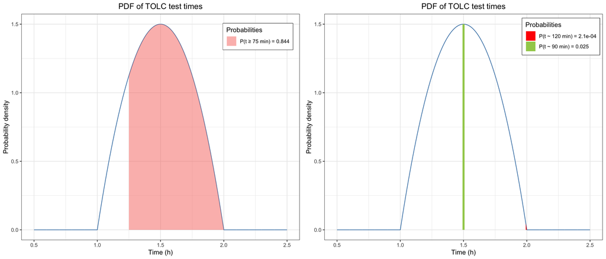

```r
prob1_plt_TOLC <- pdf_plt_TOLC +
                  labs(fill = "Probabilities") +
                  geom_area(data=pdf_TOLC,
                            aes(x=ifelse(x>=75/60, x, NA),
                                fill = paste(c("P(t ≥ 75 min) =", round(prob_more75min,3)), collapse = " ")),
                            alpha = 0.5) +
                  theme(legend.position = c(0.85,0.9), legend.box.background = element_rect(size=0.5))

prob2_plt_TOLC <- pdf_plt_TOLC +
                  labs(fill = "Probabilities") +
                  geom_area(data=pdf_TOLC,
                            aes(x=ifelse(x>=89.5/60 & x<=90.5/60, x, NA),
                                fill = paste(c("P(t ~ 90 min) =", signif(prob_90min,3)), collapse = " ")),
                            alpha = 1) +
                  geom_area(data=pdf_TOLC,
                            aes(x=ifelse(x>=119.5/60 & x<=120.5/60, x, NA),
                                fill = paste(c("P(t ~ 120 min) =", formatC(prob_120min,digits=1,format='e')), collapse = " ")),
                            alpha = 1) +
                  scale_fill_manual(values=c('red','darkolivegreen3')) +
                  theme(legend.position = c(0.85,0.9), legend.box.background = element_rect(size=0.5))

grid.arrange(prob1_plt_TOLC, prob2_plt_TOLC, nrow = 1)
```

## Exercise 6

### Exercise 6a

Write the set of the four functions (PDF, CDF, quantile function, random generation) and plot the PDF and CDF, respectively.

```r
# PDF
dtires <- Vectorize(FUN = function(x) { return(ifelse( (x>1) && (x<2), 2/x**2, 0)) })

# CDF
ptires <- Vectorize(FUN = function(q) { if (q<1) { return(0) }
                                       else if (q>2) { return(1) }
                                       else { return(integrate(dtires, lower = 1, upper = q)[["value"]]) }
                                     })

# quantile function
qtires <- Vectorize(FUN = inverse(ptires, lower = 1, upper = 2))

# random generation
rtires <- function(n) { return(qtires(runif(n, min = 0, max = 1))) }
```

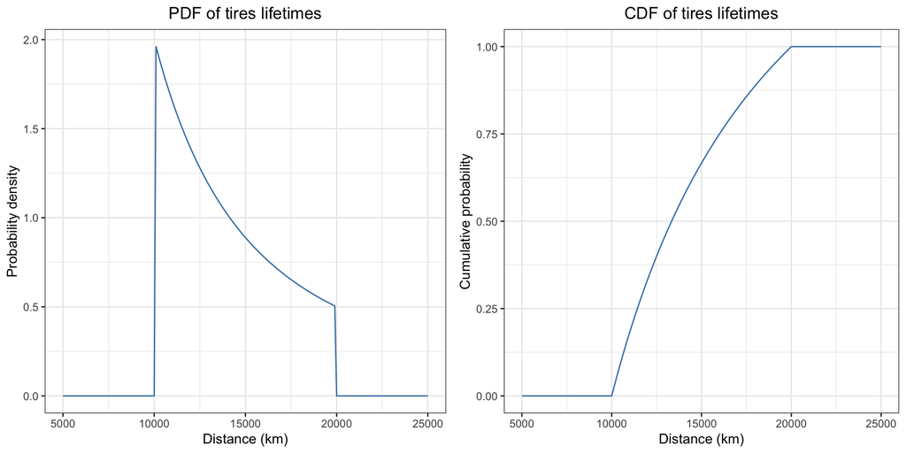

```r
x_tires <- seq(1-0.5,2+0.5,0.01)
x_tires_km <- x_tires * 10**4 #km
pdf_tires <- data.frame(x=x_tires_km, y=dtires(x_tires))
cdf_tires <- data.frame(x=x_tires_km, y=ptires(x_tires))

pdf_plt_tires <- ggplot(pdf_tires, aes(x=x, y=y)) +
                        labs(title="PDF of tires lifetimes") +
                        geom_line(data=pdf_tires, aes(x = x, y = y), color='steelblue', size=0.5) +
                        scale_x_continuous(name ="Distance (km)") +
                        scale_y_continuous(name ="Probability density") +
                        theme_bw() +
                        theme(plot.title=element_text(hjust=0.5))

cdf_plt_tires <- ggplot(cdf_tires, aes(x=x, y=y)) +
                        labs(title="CDF of tires lifetimes") +
                        geom_line(data=cdf_tires, aes(x = x, y = y), color='steelblue', size=0.5) +
                        scale_x_continuous(name ="Distance (km)") +
                        scale_y_continuous(name ="Cumulative probability") +
                        theme_bw() +
                        theme(plot.title=element_text(hjust=0.5))

grid.arrange(pdf_plt_tires, cdf_plt_tires, nrow = 1)
```

### Exercise 6b

```r
prob_less15000km <- ptires(15000/(10**4))
cat("The probability for a tire to last less than 15000 km is", round(prob_less15000km*100,1), "%\n")
```

```
The probability for a tire to last less than 15000 km is 66.7 %
```

### Exercise 6c

Sample 3000 random variables from the distribution and determine the mean value and the variance.

```r
tires_samples <- rtires(3000)

# mean
tires_mean <- mean(tires_samples)
tires_mean_km <- tires_mean * 10**4

# mean of squares
tires_mean_squares <- mean(tires_samples*tires_samples)
tires_mean_squares_km2 <- tires_mean_squares * 10**8

# variance
tires_variance <- tires_mean_squares - tires_mean**2
tires_variance_km2 <- tires_mean_squares_km2 - tires_mean_km**2


cat("The mean of the sampled lifetimes is", formatC(tires_mean_km, digits=2, format='e'), "km\n")
```

```
The mean of the sampled lifetimes is 1.39e+04 km
```

```r
cat("The variance of the sampled lifetimes is", formatC(tires_variance_km2, digits=2, format='e'), "km^2")
```

```
The variance of the sampled lifetimes is 7.81e+06 km^2
```

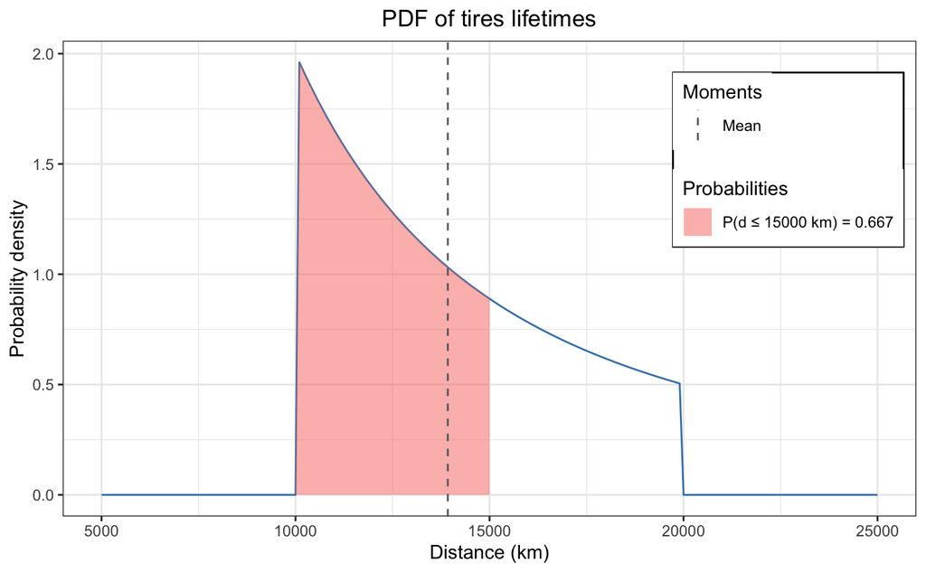

```r
prob_plt_tires <- pdf_plt_tires +
                  labs(fill = "Probabilities", color="Moments") +
                  geom_area(data=pdf_tires,
                            aes(x=ifelse(x<=15000, x, NA),
                                fill = paste(c("P(d ≤ 15000 km) =", round(prob_less15000km,3)), collapse = " ")),
                            alpha = 0.5) +
                  geom_vline(aes(xintercept = tires_mean_km, color='Mean'), linetype='dashed') +
                  scale_color_manual(values='grey40') +
                  theme(legend.position = c(0.85,0.75), legend.box.background = element_rect(size=0.5))

prob_plt_tires
```